# Capstone Final Project: Shiny App for NLP Word Predictive Model

Sunil Kumar (@sunil4data; sunil_iitb96@yahoo.co.in)  
11 Aug 2018

### 1. Introduction

- Goal of this Capstone course: -
  - Use all Data Science learning and tools to solve Next Word Predictive Modeling
  - Learn just enough of NLP around n-gram Language Modeling
  - Assess and attempt to improve accuracy and performance
- Goal of this final project: -
  - Build on the work done so far till milestone reporting (refer to http://rpubs.com/sunil4data/milesRepCapstone)
  - Create an online application (Shiny App) for Next Word Prediction
  - Provide the n-gram Language Model solution backend of Tutorial / White Paper quality (readable, reusable, scalable) https://www.kaggle.com/suniliitb96/tryswiftkeyinr?scriptVersionId=5037782

### 2. Building a predictive text model

- Create an algorithm for predicting the next word given 2 or more words as input using n-grams Language Model
- A large corpus of blog, news and twitter data was loaded and analyzed
- N-grams were extracted from 10% of corpus data and then used for building the predictive model
- Various methods of improving the prediction accuracy and speed were explored (refer to 'NLP Background study notes & findings' in https://www.kaggle.com/suniliitb96/tryswiftkeyinr?scriptVersionId=5037782)

### 4. Application Workflow

- Pre-computed LM model containing probabilities of 1,2 & 3-grams is available to Shiny App for serving Next Word Predictions
- User enters incomplete sentence of 2 or more words whose next word is to be predicted
- Same data cleaning & tokenization steps used on 'training' data is applied on this input sentence
- Input parameters of prediction algorithms
  - Add1 Laplace: None
  - Stupid Backoff: fixed value of 0.4 as Lambda
- Results
  - Cleaned input incomplte sentence
  - Prediction of 6 most probable completing words in decreasing order of probability from matching 3, 2 & 1-grams
  - Prefix of the n-gram from where this last word was picked
  - Elapsed time

### 5. Resources & App Screenshot

- [Shiny App for Word Predictive Model](https://sunil4data.shinyapps.io/data_science_capstone/)
- [GitHub url](https://github.com/sunil4data/data_science_capstone)
- [n-gram LM model learning solution code and execution report](https://www.kaggle.com/suniliitb96/tryswiftkeyinr?scriptVersionId=5037782)
- [Milestone report](http://rpubs.com/sunil4data/milesRepCapstone)

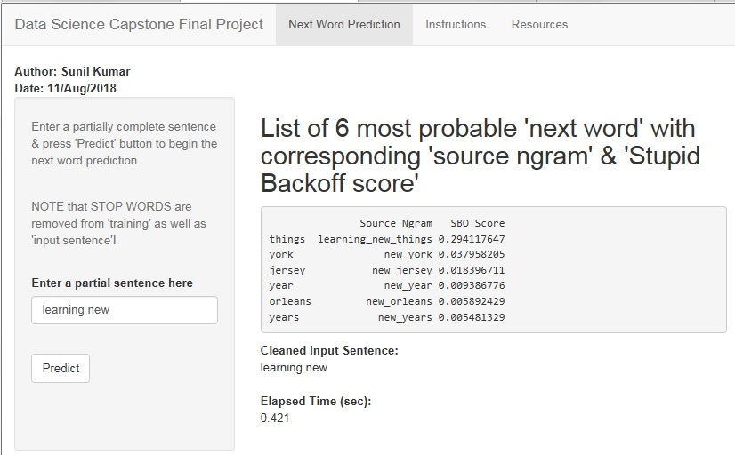